# Two independent samples

Kristopher Kyle

2/27/2019

## Measuring differences between two independent samples (t-test, Wilcoxon test)

In applied linguistics research, we often want to know whether two independent groups differ with regard to some measure of success. For example, we might have reason to beleive that a particular teaching method will lead to larger vocabulary learning gains than another. In order to test this hypothesis, we could teach Class A using a particular method (e.g., rote memorization of form-meaning pairs) and Class B with our super-special method. At the end of the instruction period, we would then give each group an identical post-test. In order to determine whether one teaching method led to better test scores than the other, we would conduct a independent samples difference test (e.g., a t-test or a Wilcoxon test).

### Conducting an independent samples t-test: Assumptions

Independent samples t-tests are rather simple tests that use the sample means and the variance in each sample to determine the probability that the two samples are part of the same population.

Following are the assumptions for an independent samples t-test: - The observations must be independent (within each sample) - Each sample is normally distributed, and the variance is equal across samples - There is only one comparison (an ANOVA is appropriate for multiple comparisons, stay tuned) - The data do not represent repeated measures (i.e., pre- and post- test scores from the same individuals) - The data is continuous

### Conducting an independent samples t-test: Visualizing the data

First, lets load some data:

```r
mydata <- read.csv("data/distribution_sample.csv", header = TRUE)
summary(mydata)
```

```
##  Prompt      Score           Nwords        Frequency
##  A:240   Min.   :1.000   Min.   : 61.0   Min.   :2.963
##  B:240   1st Qu.:3.000   1st Qu.:273.0   1st Qu.:3.187
##          Median :3.500   Median :321.0   Median :3.237
##          Mean   :3.427   Mean   :317.7   Mean   :3.234
##          3rd Qu.:4.000   3rd Qu.:355.2   3rd Qu.:3.284
##          Max.   :5.000   Max.   :586.0   Max.   :3.489
```

Then, we will load some necessary packages (don’t forget to install them if you haven’t already!):

```r
library(ggplot2) #normal ggplot
library(ggpubr) #ggplot add-on
library(psych) #psych package
```

First, we will create a box plot. As we see, the mean scores between the two prompts appear to be very similar.

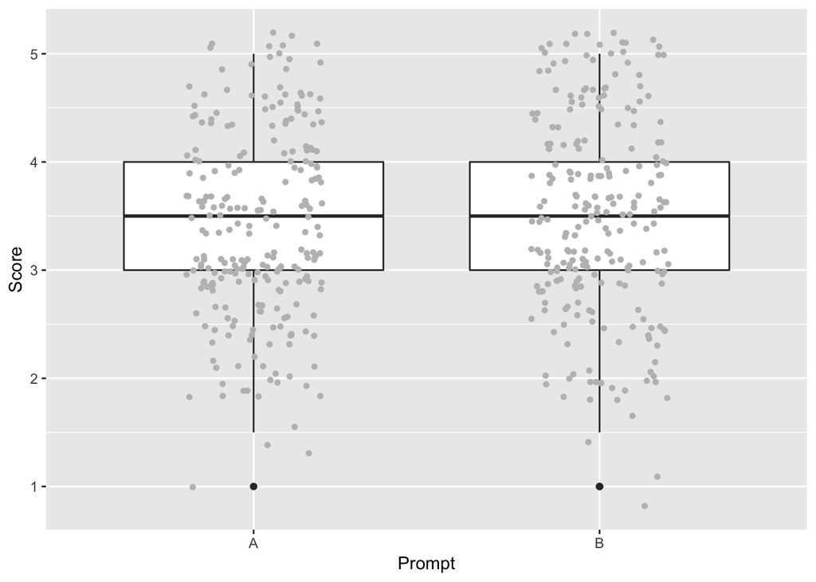

```r
#basic boxplot
ggplot(mydata, aes(x=Prompt,y=Score)) +
  geom_boxplot()+
  geom_jitter(shape=16, position=position_jitter(0.2), color = "grey")
```

Next, we will make overlapping density plots that allow us to see both the shape of the two samples and compare their means. As we can see, our samples are not perfectly normal (they are skewed to the right, among other things), and the means appear to be similar. In fact, ther seems to be a large amount of overlap between the two samples.

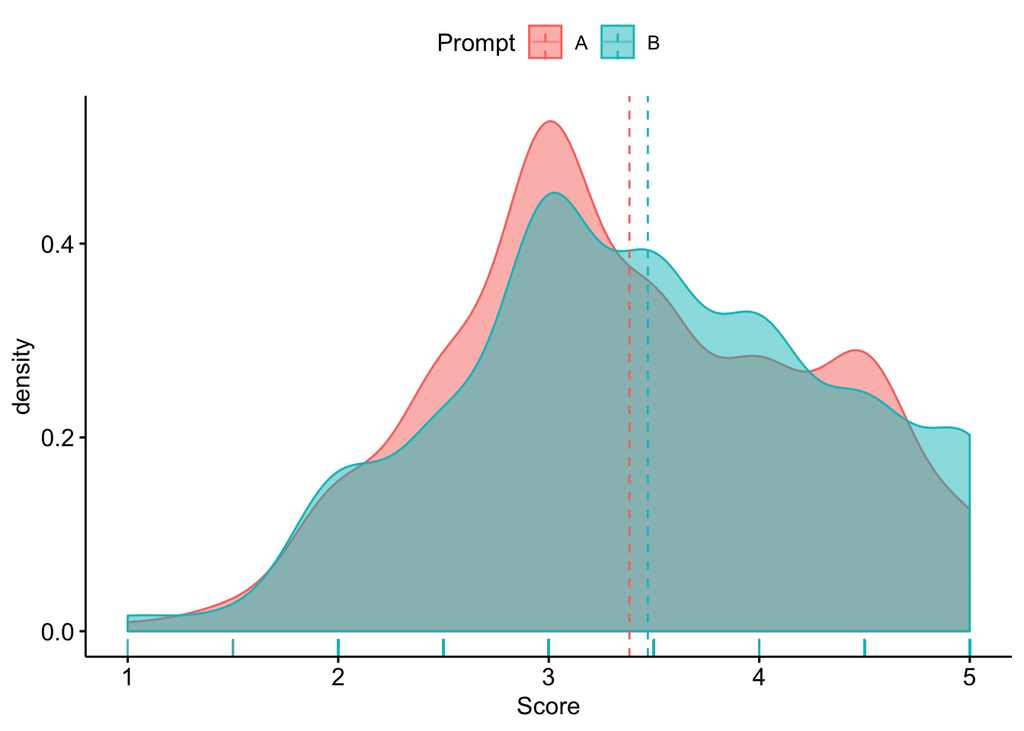

```r
#density comparison
ggdensity(mydata, x = "Score",
          add = "mean", rug = TRUE,
          color = "Prompt", fill = "Prompt")
```

Next, we will run an independent samples t-test. Remember that if you want to learn the ins and outs of what a function in R can do, you can always use “?function_name” or “help(function_name”).

```r
t.test(Score~Prompt, alternative = 'two.sided', conf.level = .95, var.equal = TRUE, data = mydata)
```

```
##
##  Two Sample t-test
##
## data:  Score by Prompt
## t = -1.0807, df = 478, p-value = 0.2804
## alternative hypothesis: true difference in means is not equal to 0
## 95 percent confidence interval:
##  -0.24659456  0.07159456
## sample estimates:
## mean in group A mean in group B
##        3.383333        3.470833
```

Finally, we will check the effect size:

```r
cohen.d(mydata,"Prompt")
```

```
## Call: cohen.d(x = mydata, group = "Prompt")
## Cohen d statistic of difference between two means
##           lower effect    upper
## Score     -0.08  0.099  0.27789
## Nwords    -0.36 -0.181 -0.00093
## Frequency -0.22 -0.046  0.13305
##
## Multivariate (Mahalanobis) distance between groups
## [1] 0.35
## r equivalent of difference between two means
##     Score    Nwords Frequency
##     0.049    -0.090    -0.023
```

### Mann-Whitney **U** test (Wilcoxon rank-sum test)

If your data do not meet the assumptions of the independent samples t-test, the Mann-Whitney **U** test (also called a Wilcoxon rank-sum test) is an option.

Conducting the Mann-Whitney **U** test is straightforward in R. Note that your continuous variable should come first, followed by your dichotomouse variable.

```r
wilcox.test(Score~Prompt,data = mydata)
```

```
##
##  Wilcoxon rank sum test with continuity correction
##
## data:  Score by Prompt
## W = 27058, p-value = 0.2449
## alternative hypothesis: true location shift is not equal to 0
```

The test indicated that there are NO significant differences in Score between essays written in response to Prompt A and essays written in response to Prompt B.

```r
library(rcompanion) #don't forget to install if you haven't already
wilcoxonR(mydata$Score,mydata$Prompt)
```

```
##      r
## 0.0531
```

As expected based on our previous calculations, the effect size is quite low (and is well below our threshold for a “small” effect.)

### Time for practice!

Now, determine whether there are differences between prompts for Nwords and Frequency. Don’t forget to check for assumptions!